# Презентация по лабораторной работе №1

Установка и конфигурация операционной системы на виртуальную машину

Лушин А.А.

Российский университет дружбы народов, Москва, Россия

Факультет Физико-математических и естественных наук

# Информация

## Докладчик

- Лушин Артём Андреевич
- Бакалавр направления компьютерные и информационные науки
- Кафедра теории вероятности и кибербезопасности
- Российский университет дружбы народов
- Редактор Первого Федерального канала
- lusin5745@gmail.com

# Вводная часть

## Цели и задачи

- Приобретение практических навыков установки операционной системы на виртуальную машину, настройки минимально необходимых для дальнейшей работы сервисов.

# Ход работы

## Создание новой виртуальной машины

В самом начале работы мы создаём новую виртуальную машину. Предварительно необходимо скачать программу VirtualBox. При создании указываем название машины, тип операционной системы, папку, где будут располагаться файлы и версию возможной ОС.

[figure not shown]

## Основная память и процессоры

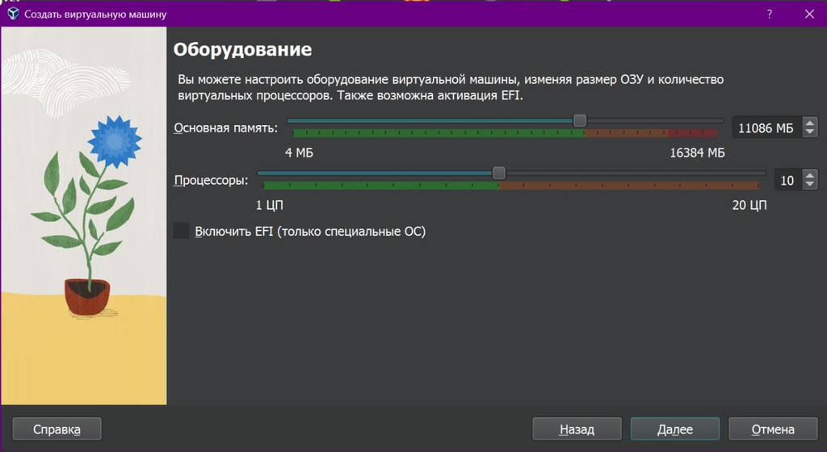

## Добавление жёсткого диска

Следующее окно - это окно добавления жёсткого диска. Мы можем создать как виртуальный диск, так и добавить уже существующий. При создании виртуального диска мы выбираем количество памяти, которые выделяется для использования.

[figure not shown]

## Запуск ОС

После запуска машины мы ждём какое-то время, так как первый запуск будет довольно долгим. После чего мы выбираем огромное количество функций: язык, раскладка, время, оборудование, интернет, пользователя, root-пользователя и так далее.

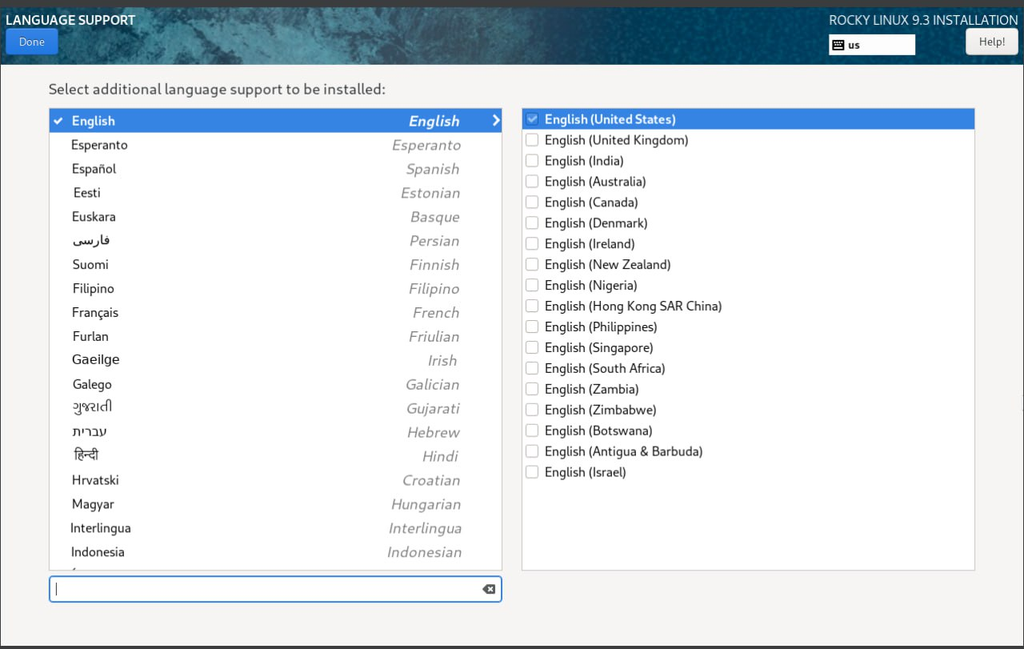

## Команда dmesg

Домашним заданием была работа с командой dmesg. Команда используется для поиска какой либо информации. Так же есть большое количество дополнительный функций. Например, с помощью добавочного слова grep мы можем искать по конкретному слову информацию. Очень удобно использовать, если необходимо найти какую-то версии приложения и тд.

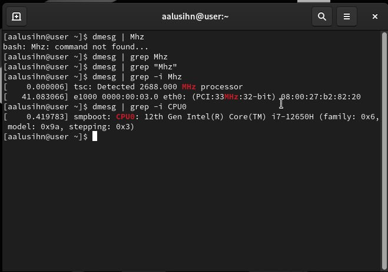

# Результаты

## Вывод

Я приобрёл практические навыки установки операционной системы на виртуальную машину. Настроил минимально необходимые для дальнейшей работы сервисы

## Контрольные вопросы

1. Какую информацию содержит учётная запись пользователя?

Учётная запись пользователя - это запись, которая содержит сведения, необходимые для идентификации пользователя при подключении к системе, а также информацию для авторизации и учёта. Это имя пользователя и пароль

2. Укажите команды терминала и приведите пример
- для получения справки по команде: имя программы –help. dmesg –help
- для перемещения по файловой системе: cd путь. cd work
- для просмотра содержимого каталога: ls - l. ls work
- для определения объёма каталога du имя_папки. du work
- для создания / удаления каталогов / файлов: создание каталога - mkdir, удаление файла или каталога - rm -r, создание файла - touch
- для создания определённых прав на файл/каталог: chmod разрешение имя_файла. chown новый_владелец - для смены владельца
- для просмотра историй команд: history
3. Что такое файловая система? Приведите пример с краткой характеристикой.

Фа́йловая систе́ма (англ. file system) — порядок, определяющий способ организации, хранения и именования данных на носителях информации в компьютерах, а также в другом электронном оборудовании: цифровых фотоаппаратах, мобильных телефонах и т. п.

• Для носителей с произвольным доступом (например, жёсткий диск): FAT32, HPFS, ext2 и др. Поскольку доступ к дискам в несколько раз медленнее, чем доступ к оперативной памяти, для прироста производительности во многих файловых системах применяется асинхронная запись изменений на диск. Для этого применяется либо журналирование, например, в ext3, ReiserFS, JFS, NTFS, XFS, либо механизм soft updates и др. Журналирование широко распространено в Linux, применяется в NTFS. Soft updates — в BSD системах.

• Для носителей с последовательным доступом (например, магнитные ленты): QIC и др.

• Для оптических носителей — CD и DVD: ISO9660, HFS, UDF и др.

• Виртуальные файловые системы: AEFS и др.

• Сетевые файловые системы: NFS, CIFS, SSHFS, GmailFS и др.

• Для флэш-памяти: YAFFS, ExtremeFFS, exFAT

4. Как посмотреть, какие файловые системы подмонтированы в ОС?

$ findmnt –mtab

5. Как удалить зависший процесс?

команды: kill, pgrep, pkill, killall